# Научная презентация 6

Дисциплина:Операционные системы

Алехин Давид Андреевич

Российский университет дружбы народов, Москва, Россия

Математический институт имени Никольского, Москва, Россия

06.03.25

# Информация

## Докладчик

- Алехин Давид Андреевич
- Студент
- Студент НММбд-01-24
- Российский университет дружбы народов
- 1132246830@pfur.ru
- https://github.com/trustdef

[figure not shown]

# Элементы презентации

## Актуальность

- Важно уметь работать с файловой системой.

## Цели и задачи

- Приобретение практических навыков взаимодействия пользователя с системой по- средством командной строки.

## Материалы и методы

- fedora-linux

## Содержание исследования

Выполняю пункт 1. Выполняю пункт 2.1 (рис. [-@fig:001]).

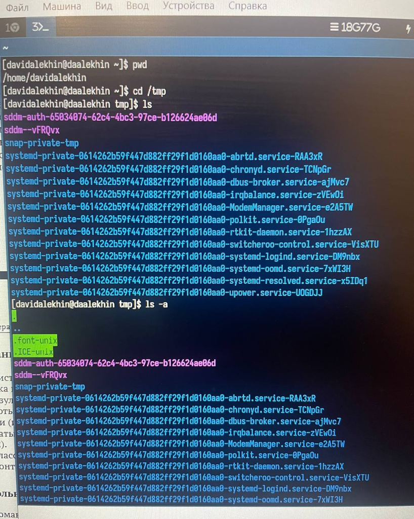

1

## Содержание исследования

Выполняю пункт 2.2. С помощью различных опций команды ls вывожу содержимое на экран( меняется предоставляемая информация и файлы , который можно видеть ) (рис. [-@fig:002]).

[figure not shown]

2

## Содержание исследования

[figure not shown]

2-3

## Содержание исследования

Выполняю пункт 3.3. Выполняю пункт 3.4 (Нет , не был удалён). Выполняю пункт 3.5 (Удаляю morefun, убеждаюсь , что удалён)Выполняю пункт 4 (Надо использовать опцию -R). Выполняю пункт 5 (Надо использовать опцию -l). Выполняю пункт 6 ( rm удаляет каталоги, которые могут содержать содержимое, включая файлы и подкаталоги. rmdir удаляет только пустые каталоги. Если каталог содержит файлы или подкаталоги, эта команда не будет работать. Cd - перемещение по системе Pwd полный путь к файлу Mkdir создание директори) (рис. [-@fig:004]).

[figure not shown]

3-6

## Содержание исследования

Выполняю пункт 7 (рис. [-@fig:005]).

[figure not shown]

7

## Результаты

В итоге я выполнил основную цель работы: Приобретение практических навыков взаимодействия пользователя с системой по- средством командной строки.

## Итоговый слайд

В теории, теория и практика неразделимы. На практике это не так. Yoggi Berra